# Analiza tvitov ruskih trolov

## Člani skupine

- Žan Bizjak
- Gašper Mrak
- Matej Fajdiga
- Uroš Koritnik
- Jakob Kovačič

## Opis problema

Za projekt pri predmetu smo si izbrali podatkovno analizo tvitov ruskih "trolov", s katerimi naj bi Rusija vplivala na Ameriške volitve. Analizirali bomo vsebine tvitov, lastnosti računov in preko tega poskusili ugotoviti razne vzorce v objavah - najpogostejše fraze, prevladujoče "heštege", ciljne skupine, časovne intervale ipd. Hkrati bi tudi lahko vpeljali tvite in račune dejanskih uporabnikov, primerjali rezultate in tako morda ugotovili ključne razlike med njima.

## Podatki

[Začetne podatke](https://www.kaggle.com/vikasg/russian-troll-tweets), ki vsebujejo 200.000 tvitov, smo pridobili s Kaggla, in sicer dve CSV datoteki: "tweets" in "users". Prva vsebuje podatke o tvitih, druga pa o uporabnikih. Relacijsko se povezujeta prek atributa "user_id".

Med raziskavo smo naleteli na [še večji nabor podatkov](https://github.com/fivethirtyeight/russian-troll-tweets), ki vsebuje 3 milijone tvitov ruskih trolov. Te bomo po končani analizi manjšega nabora uporabili za primerjavo rezultatov.

```python
import numpy as np
import pandas as pd
import matplotlib.pyplot as plt
import ast
import warnings
import math
import seaborn as sb
import networkx as nx
warnings.filterwarnings('ignore')
plt.style.use('fivethirtyeight')
```

```python
tweets_data = pd.read_csv("podatki/tweets.csv", dtype=object)
users_data = pd.read_csv("podatki/users.csv", dtype=object)

users_data['created_at'] = pd.to_datetime(users_data['created_at'])
tweets_data['created_str'] = pd.to_datetime(tweets_data['created_str'])
```

## Časovna porazdelitev uporabnikov

```
Text(0,0.5,'count')
```

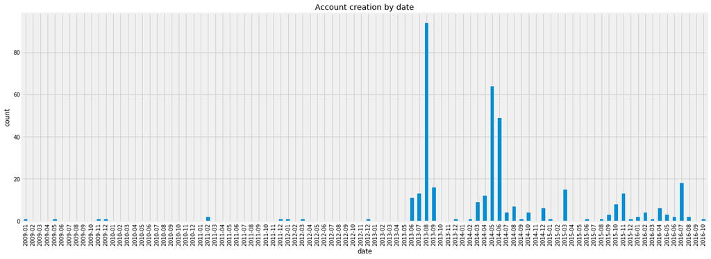

```python
users_data['month'] = users_data['created_at'].dropna().dt.to_period('M')
months = users_data['month'].dropna().sort_values()
index = pd.PeriodIndex(start=months.iloc[0], end=months.iloc[-1])
users_data.groupby('month')['created_at'].count().reindex(index).plot.bar(figsize=(20,7), linewidth=1)
plt.title('Account creation by date')
plt.xlabel('date')
plt.ylabel('count')
```

## Časovna porazdelitev tweetov

```
Text(0,0.5,'count')
```

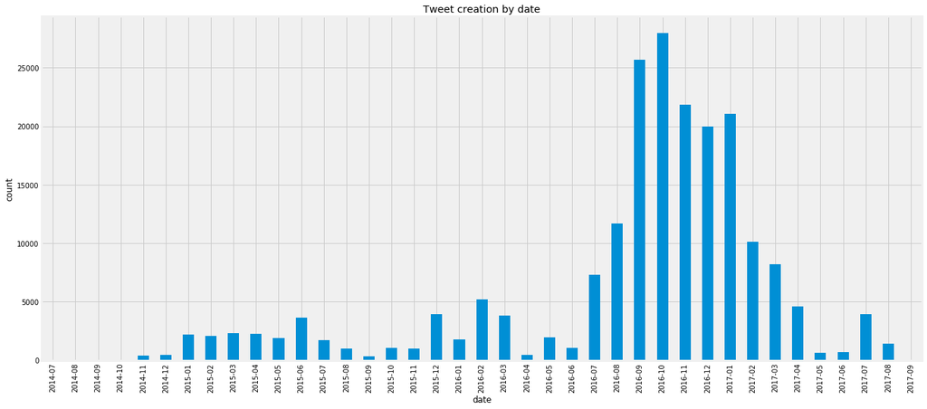

```python
tweets_data['month'] = tweets_data['created_str'].dropna().dt.to_period('M')
months = tweets_data['month'].dropna().sort_values()
index = pd.PeriodIndex(start=months.iloc[0], end=months.iloc[-1])
tweets_data.groupby('month')['created_at'].count().reindex(index).plot.bar(figsize=(20,9), linewidth=1)
plt.title('Tweet creation by date')
plt.xlabel('date')
plt.ylabel('count')
```

## Hashtagi

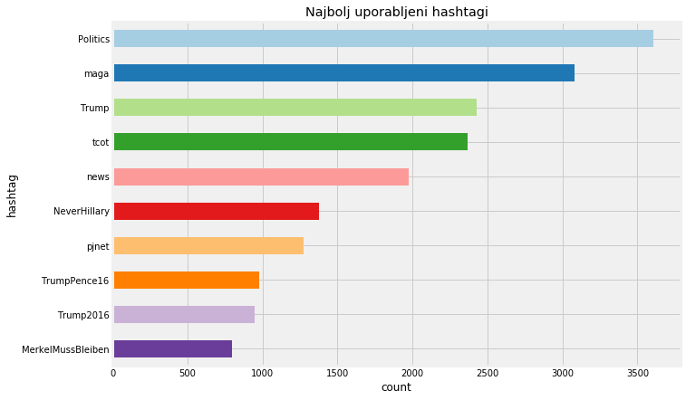

```python
hashtags = np.array(tweets_data['hashtags'].apply(ast.literal_eval))
top10_hashtags = pd.Series(np.hstack(hashtags)).value_counts().nlargest(10)
top10_hashtags.T.plot(kind='barh', figsize=(10, 7), color=plt.cm.Paired(np.arange(len(top10_hashtags))))
plt.title('Najbolj uporabljeni hashtagi')
plt.xlabel('count')
plt.ylabel('hashtag')
plt.gca().invert_yaxis()
```

## Omenjeni uporabniki

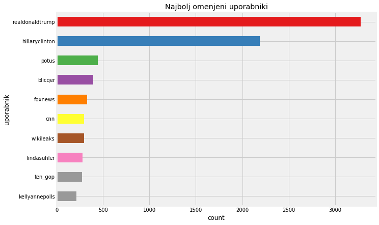

```python
mentions = np.array(tweets_data['mentions'].apply(ast.literal_eval))
top10_mentions = pd.Series(np.hstack(mentions)).value_counts().nlargest(10)
top10_mentions.plot(kind='barh', figsize=(10, 7), color=plt.cm.Set1(np.arange(len(top10_mentions))))
plt.title('Najbolj omenjeni uporabniki')
plt.xlabel('count')
plt.ylabel('uporabnik')
plt.gca().invert_yaxis()
```

## Povezanost uporabnikov

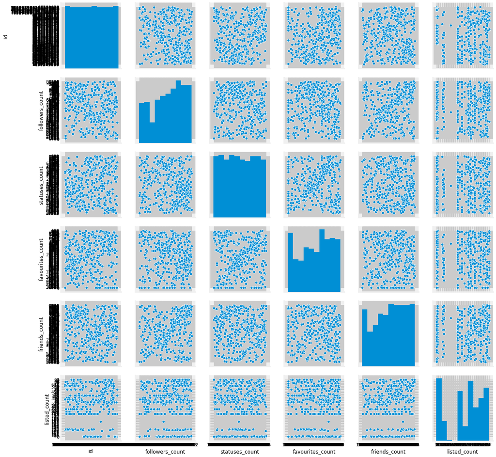

```python
users = pd.read_csv("podatki/users.csv", sep=",", dtype=object)
users = users[pd.notnull(users['id'])]
sb.pairplot(users)
```

### Korelacija podatkov pri uporabnikih.

Zgornji grafi so grafi ki prikazujejo povezavo med vsemi atributi med sabo. Pri večini atributov se takojšnje povezave ne opazi, le pri atributih *friends_count* - *followers_count* in *favourtites_count* - *statuses_count* se opazi zgostitev točk po diagonali. Na koncu teh korelacij nisem porabil nikjer.

```python
tweets_data = pd.read_csv("podatki/tweets.csv", dtype=object)
tweets_data = tweets_data[pd.notnull(tweets_data['user_id'])]

retweeted_status_ids = tweets_data['retweeted_status_id'].loc[pd.notnull(tweets_data['retweeted_status_id'])]
retweeted_df = tweets_data[pd.notnull(tweets_data['retweeted_status_id'])]

retweets = tweets_data['tweet_id'].loc[tweets_data['tweet_id'].isin(retweeted_status_ids)]
retweets_df = tweets_data[tweets_data['tweet_id'].isin(retweeted_status_ids)]
```

```python
retweeted_tweets_from_dataset = tweets_data[tweets_data['tweet_id'].isin(retweeted_status_ids)]['tweet_id']

connections = tweets_data[tweets_data['retweeted_status_id'].isin(retweeted_tweets_from_dataset)]
connections = connections[['tweet_id','retweeted_status_id' ]]
```

### Razlaga kode

Zgonja koda prebere vse tweete iz .csv datoteke, nato pa odstrani vse tweete, pri katerih nam user_id ni znan (NaN). Nato ustvarim seznam vseh tweet_id-jev, ki so bili retweetani v tem datasetu.

Potem ustvarim now Dataframe, ki vsebuje samo tiste tweete, kateri so retweetali tweete iz tega dataseta. Tako dobimo Dataframe tweetov, ki so bili retweetani med boti.

Ustvaril sem še connections Dataframe. Ta vsebuje samo dva atributa: *tweet_id* in *retweeted_status_id*, s tem si poenostavim gradnjo spodnjih grafov.

```python
G = nx.DiGraph()
for i in connections.values:
    G.add_edge(i[0], i[1])
most_retweeted =  sorted(G.degree, key=lambda x: x[1], reverse=True)[:1][0][0]
print("Najbolj retweetan tweet med boti je: \n")
print(tweets_data[['user_key', 'text']].loc[tweets_data['tweet_id'] == most_retweeted])
```

```
Najbolj retweetan tweet med boti je:

          user_key               text
37404  notritahart  #HowToLoseYourJob
```

S pomočjo networkx knjižnice sem ustvaril usmerjen graf. Povezave na grafu delujejo tako, da je povezava med dvema tweetoma usmerjena v smeri originalnega tweeta. Torej retweet kaže proti originalnem tweetu.

Naredila se je še kratka analiza, kater tweet ima največjo stopnjo v grafu. Izkazalo se je da je to tweet uporabnika **notritahart** z vsebino: "#HowToLoseYourJob"

```
<function matplotlib.pyplot.show(*args, **kw)>
```

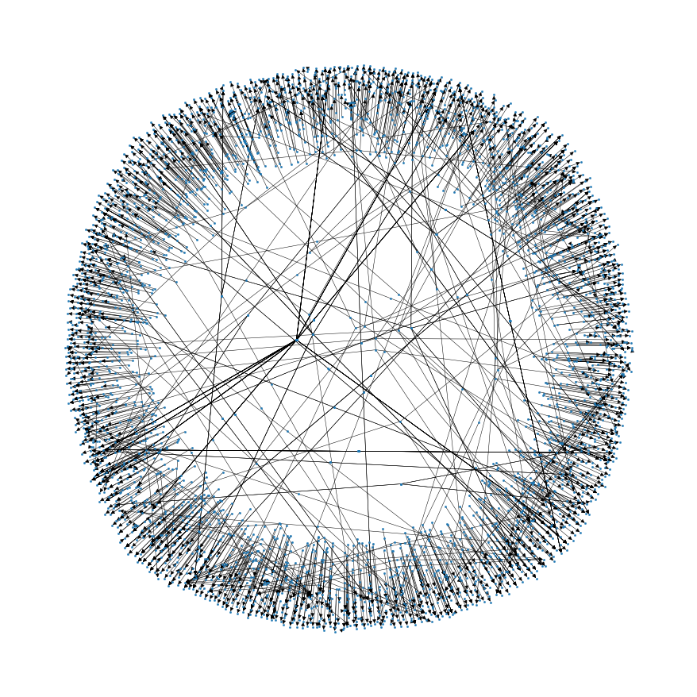

```python
plt.figure(3, figsize=(12, 12))
nx.draw(G, pos=nx.spring_layout(G), with_labels=False, node_size=5, width=0.5)
plt.show
```

Ko izrišemo graf se opazi da veliko tweetov bilo retweetanih samo enkrat. Taki tweeti nam ne povejo veliko in na grafu delajo navlako. Zato sem vsa vozlišča (tweete), ki imajo stopnjo manj kot dve zbrisal. Po tem ostane veliko novih vozlišč z stopnjo 0, tako da tista vozlišče zbrišem posebaj

```python
node_list = G.node()
remove = []
for i in node_list:
    if G.degree(i) < 2:
        remove.append(i)
len(remove)
G.remove_nodes_from(remove)

node_list = G.node()
remove = []
for i in node_list:
    if G.degree(i) == 0:
        remove.append(i)
len(remove)
G.remove_nodes_from(remove)
```

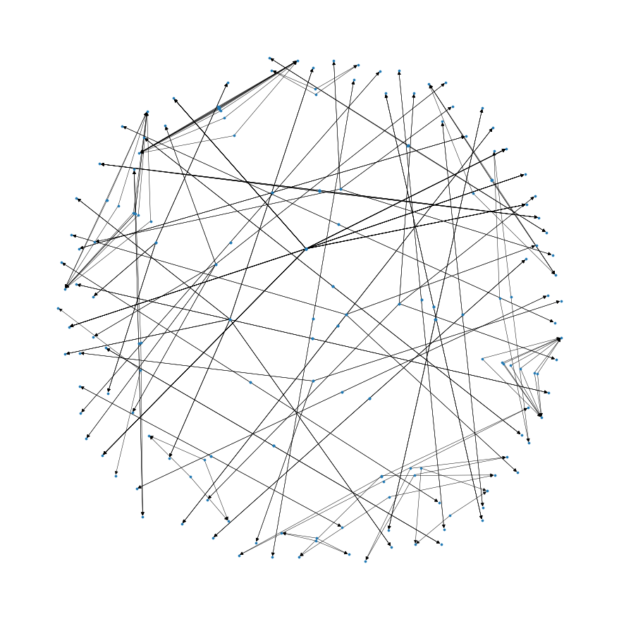

```python
plt.figure(3, figsize=(12, 12))
nx.draw(G, pos=nx.spring_layout(G, k=0.05), with_labels=False, node_size=10, width=0.5)
plt.show()
```

Ko je graf očiščen, se opazi zanimiva mreža. Večina vozlišč z višjimi stopnjami so tista, ki so retweetali. Je pa nekaj originalnih tweetov, ki so bili velikokrat retweetani

```python
userGraph = nx.DiGraph()
for i in connections.values:
    r_usr = tweets_data['user_id'].loc[tweets_data['tweet_id'] == i[0]].iloc[0]
    o_usr = tweets_data['user_id'].loc[tweets_data['tweet_id'] == i[1]].iloc[0]
    userGraph.add_edge(r_usr, o_usr)
```

### Boti, katere so ostali boti največkrat retweetali

Ustvaril sem nov graf, ta ima tokrat za vrednost vozlišča id uporabnika, ki je tweetal določen tweet. Za povezave se je še vedno uporabil Dataframe connections. Iz tweet_id-ja in retweeted_status_id-ja sem pridobil user_id uporabnika ki je tweetal določen tweet.

Prikaz naslednjega grafa je zelo zanimiv

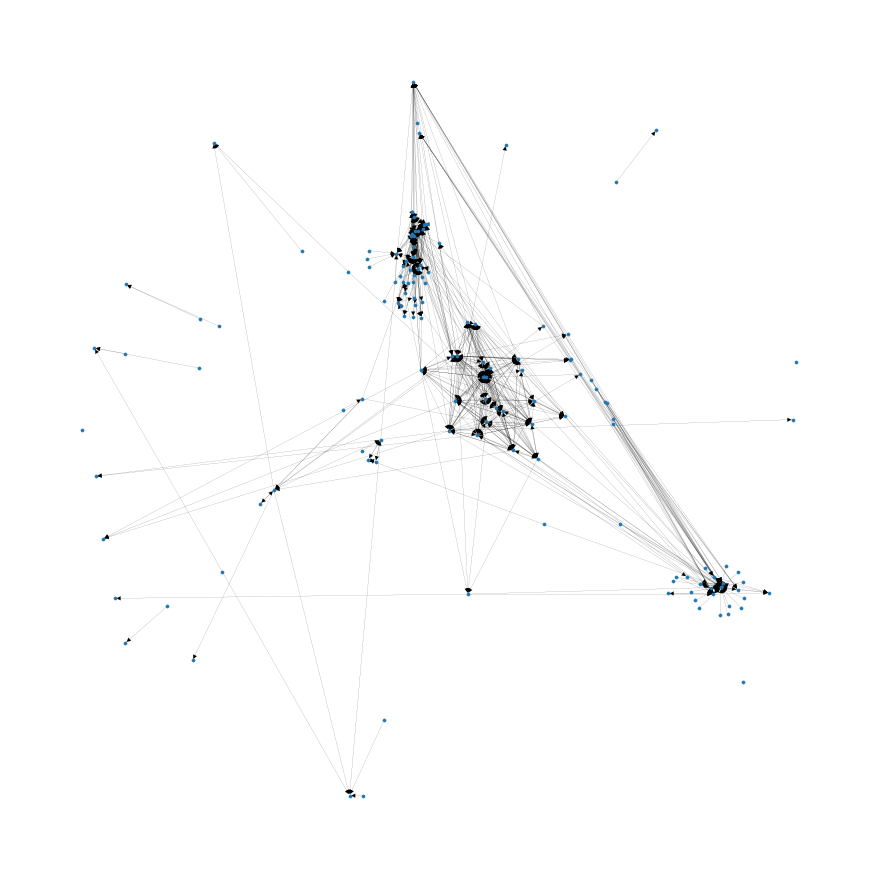

```python
plt.figure(3, figsize=(12, 12))
nx.draw(userGraph, pos=nx.spring_layout(userGraph), with_labels=False, node_size=10, width=0.1)
plt.show()
```

Zgornji graf nam prikaže da obstajajo boti, katere so ostali boti v večjih številih retweetali. Tista vozlišča, katera so obdana s puščicami pomeni da je drugih uporabnikov retweetalo tweete tega uporabnika.

```python
maxUser = None
maxDeg = -math.inf
for k, v in userGraph.degree():
    if maxUser == None:
        maxUser = k
        maxDeg = v
        continue
    if v > maxDeg:
        maxUser = k
        maxDeg = v
print("{}: {}".format(maxUser, maxDeg))
print(tweets_data[tweets_data['user_id'] == maxUser]['user_key'].sample(1).values[0])
```

```
4224729994: 51
ten_gop
```

```python
top_ten=sorted(userGraph.degree, key=lambda x: x[1], reverse=True)[:10]
for k, v in top_ten:
    print(tweets_data[tweets_data['user_id'] == k]['user_key'].sample(1).values[0])
```

```
ten_gop
giselleevns
michellearry
garrettsimpson_
_nickluna_
heyits_toby
melvinsroberts
leroylovesusa
jeffreykahunas
emileewaren
```

Po analizi vozlišč, sem izpisal uporabniška imena tistih botov, ki imajo največje stopnje. Največjo stopnjo je imel uporabnik ten_gop. V naši bazi uporabnikov, zgleda kot nič posebnega, vendar z malo brskanja po spletu, se razvidi da je to eden od bolj vplivnih twitter botov. Uporabniško ime bota se je celo prikazal na eni izmed Muellerjevih [obtožnic](https://www.documentcloud.org/documents/4380502-Indictment.html#document/p15/a404968)